# 第一题：决策树处理分类任务

1. 使用sklearn.tree.DecisionTreeClassifier完成dota2比赛结果预测问题
2. 计算最大深度为10时，十折交叉验证的精度(accuracy)，查准率(precision)，查全率(recall)，F1值
3. 绘制最大深度从1到10的决策树十折交叉验证精度的变化图

## 1. 读取数据

```python
import numpy as np
dota2results = np.loadtxt('data/dota2Dataset/dota2Train.csv', delimiter=',')
```

```python
dota2x = dota2results[:, 1:]
dota2y = dota2results[:, 0]
```

## 2. 导入模型

```python
from sklearn.model_selection import cross_val_predict
from sklearn.metrics import accuracy_score
from sklearn.metrics import precision_score
from sklearn.metrics import recall_score
from sklearn.metrics import f1_score
from sklearn.tree import DecisionTreeClassifier
```

## 3. 训练与预测

计算最大深度为10的决策树，在使用数据dota2x，标记dota2y下，十折交叉验证的精度，查准率，查全率和F1值

```python
model = DecisionTreeClassifier(max_depth = 10) # 参数max_depth决定了决策树的最大深度
# YOUR CODE HERE
prediction = cross_val_predict(model, dota2x, dota2y, cv = 10)

acc  = accuracy_score(dota2y, prediction)
pre_s = precision_score(dota2y, prediction)
rec_s = recall_score(dota2y, prediction)
f1_s = f1_score(dota2y, prediction)

print('精度: ', acc)
print('查准率: ', pre_s)
print('查全率: ', rec_s)
print('F1值: ', f1_s)
```

```
精度:  0.5506529951430114
查准率:  0.5566525101419878
查全率:  0.720081177483498
F1值:  0.627906976744186
```

###### 双击此处填写下面的表格

最大深度为10：

[output not shown]

## 4. 改变最大深度，绘制决策树的精度变换图

绘制最大深度从1到10，决策树十折交叉验证精度的变化图

```python
import matplotlib.pyplot as plt
%matplotlib inline
```

```python
# YOUR CODE HERE
accs = []
for i in range(1, 11):
    accs.append(accuracy_score(dota2y, cross_val_predict(DecisionTreeClassifier(max_depth = i), dota2x, dota2y, cv = 10)))

print(accs)
```

```
[0.5265191581219644, 0.5263248785752833, 0.5335563950350782, 0.5366216945493794, 0.5387048030221263, 0.5438316243928765, 0.5459255261737722, 0.5485159201295197, 0.5496815974096061, 0.5505666486778198]
```

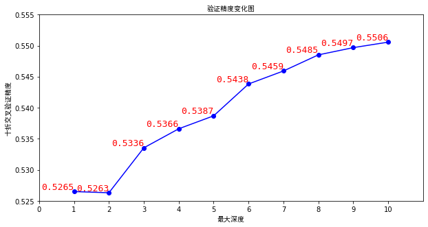

```python
x = list(range(1, 11))

plt.figure(figsize=(10, 5))
plt.xlim((0, 11))
plt.ylim((0.525,0.555))
plt.xlabel('最大深度', fontproperties='SimHei')
plt.ylabel('十折交叉验证精度', fontproperties='SimHei')
plt.xticks(np.linspace(0, 10, 11))
plt.title('验证精度变化图', fontproperties='SimHei')

for i in range(len(x)):
    plt.text(x[i], accs[i], "{:.4f}".format(accs[i]), family='monospace', verticalalignment='bottom',
             horizontalalignment='right', color='r', fontsize=13)

plt.plot(x, accs, 'o-', color='b')
plt.show()
```

# 5. （选做）通过调整参数，得到一个泛化能力最好的模型

查看决策树文档，通过调整决策树的参数，得到一个最好的模型  
http://scikit-learn.org/stable/modules/generated/sklearn.tree.DecisionTreeClassifier.html#sklearn.tree.DecisionTreeClassifier  
并在下方给出参数的设定与其泛化性能指标

```python
# YOUR CODE HERE
```

[figure not shown]

[figure not shown]

[figure not shown]

[figure not shown]

[figure not shown]

[figure not shown]

[interactive chart not shown]